## Research Internship - Summer 2021

## Data analysis for OSHA “Occupational Safety and Health Administration”

## Additional task: Verify data accuracy

## —————————————————————————————————

## Part One:

## a. Load packages and dataset

## b. Data cleaning

```
## [1] "Table that confirm if NA values are successfuly removed from the variables."
```

```
## [1] "Variable #1: Reporting ID's"
```

```
##
## 936100 936200 950611 950612 950614 950615 950621 950622 950623 950624 950625
##     36     96      1     21      8     52     27     34      9     50    122
## 950631 950632 950633 950636 950641 950642 950643 950644 950646 950647
##     15     64     96     10     15      5     72     31      1     32
```

```
## [1] "Variable #2: Owner Type"
```

```
##
##   A   B   C   D
##  18 123 524 132
```

```
## [1] "Variable #3: Violation Type"
```

```
##
##   O   R   S
## 595  13 189
```

## —————————————————————————————————

## Part Two: Table of Violation Reported by Owner Type

```
##        A = Private B = Local Govt C = State Govt D = Federal
## 936100           0              0              0          36
## 936200           0              0              0          96
## 950611           0              1              0           0
## 950612           0             10             11           0
## 950614           0              8              0           0
## 950615           0              5             47           0
## 950621           0              6             21           0
## 950622           0              4             30           0
## 950623           0              2              7           0
## 950624           0              9             41           0
## 950625           0              6            116           0
## 950631           0             13              2           0
## 950632           8              4             52           0
## 950633           6              1             89           0
## 950636           0              2              8           0
## 950641           0              9              6           0
## 950642           0              0              5           0
## 950643           2             39             31           0
## 950644           2              4             25           0
## 950646           0              0              1           0
## 950647           0              0             32           0
```

### Total sum per column:

```
##    A = Private B = Local Govt C = State Govt    D = Federal
##             18            123            524            132
```

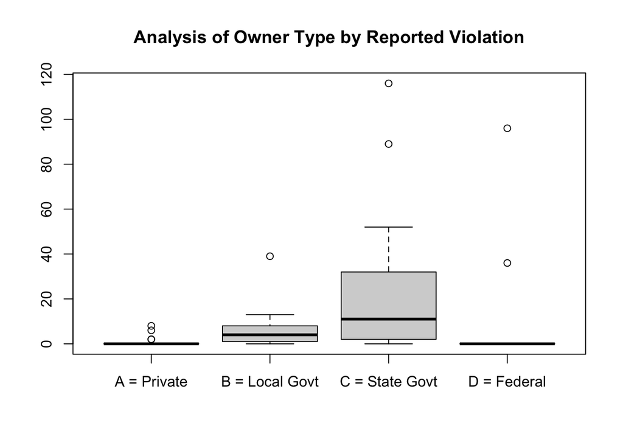

*We understand from the plot that state government have the highest reported violation whereas private facilities have the lowest reported violation compared to the other owners. We do not know if private facilities were very cautious from violation to prevent higher violation fees or to protect their license from cancellation. They have the lowest violation from the other type of facilities.*

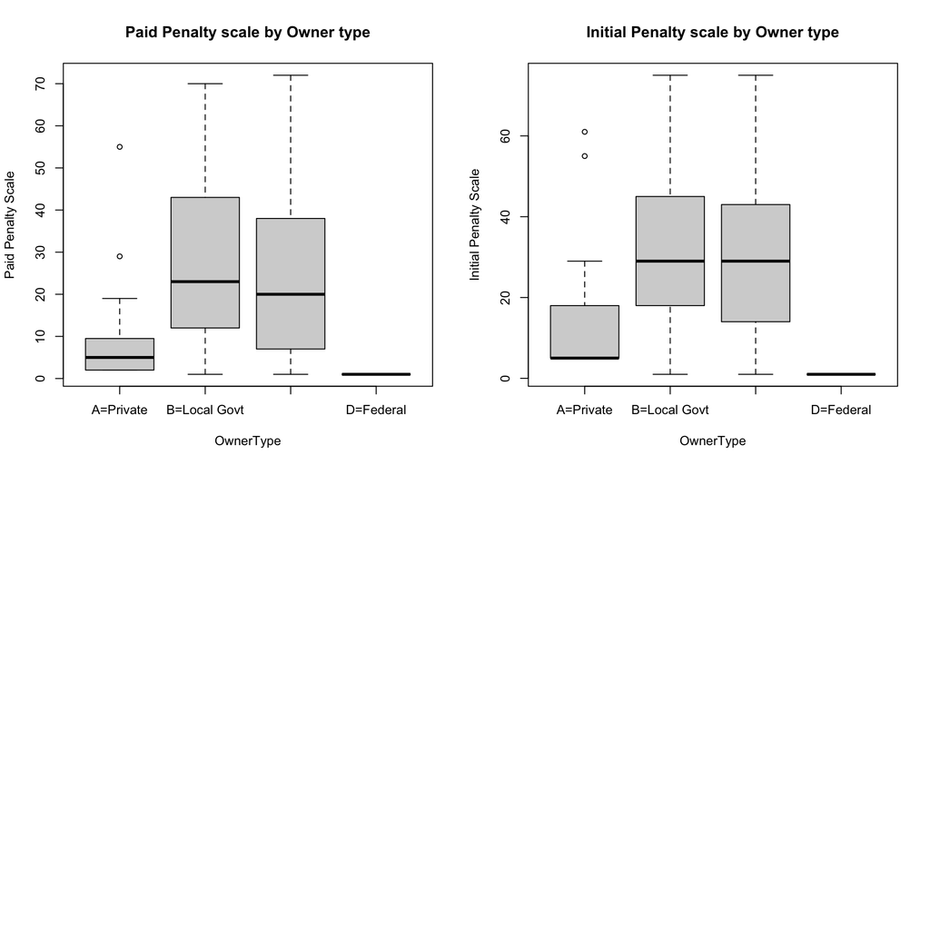

## —————————————————————————————————

## Part Three:

## 1. Violation report for “C” State Governed Facility

```
##        O = Other R = Repeat S = Serious
## 950612        11          0           0
## 950615        39          0           8
## 950621        16          0           5
## 950622        28          0           2
## 950623         7          0           0
## 950624        40          0           1
## 950625        96          1          19
## 950631         2          0           0
## 950632        47          0           5
## 950633        73          0          16
## 950636         8          0           0
## 950641         5          0           1
## 950642         5          0           0
## 950643        28          0           3
## 950644        21          3           1
## 950646         1          0           0
## 950647        29          0           3
```

### Total sum per column:

```
##   O = Other  R = Repeat S = Serious
##         456           4          64
```

### Selected Inspection Number:

### Repeated Violation ONLY

```
## # A tibble: 4 x 3
## # Groups:   owner_type [1]
##   owner_type activity_nr viol_type
##   <chr>            <int> <chr>
## 1 C            343012779 R
## 2 C            343378477 R
## 3 C            343378477 R
## 4 C            343827929 R
```

## 2. Violation report for “B” Local Governed Facility

```
##        O = Other R = Repeat S = Serious
## 950611         1          0           0
## 950612        10          0           0
## 950614         2          0           6
## 950615         5          0           0
## 950621         5          0           1
## 950622         2          0           2
## 950623         1          0           1
## 950624         9          0           0
## 950625         6          0           0
## 950631        13          0           0
## 950632         4          0           0
## 950633         0          0           1
## 950636         2          0           0
## 950641         9          0           0
## 950643        35          0           4
## 950644         3          1           0
```

### Total sum per column:

```
##   O = Other  R = Repeat S = Serious
##         107           1          15
```

### Selected Inspection Number:

### 1) Repeated Violation:

```
## # A tibble: 1 x 3
## # Groups:   owner_type [1]
##   owner_type activity_nr viol_type
##   <chr>            <int> <chr>
## 1 B            316346360 R
```

### 2) Serious Violation:

```
## # A tibble: 15 x 3
## # Groups:   owner_type [1]
##    owner_type activity_nr viol_type
##    <chr>            <int> <chr>
##  1 B            313231045 S
##  2 B            314325325 S
##  3 B            314325325 S
##  4 B            314822669 S
##  5 B            314824228 S
##  6 B            314824228 S
##  7 B            315315416 S
##  8 B            315315416 S
##  9 B            315315416 S
## 10 B            315315416 S
## 11 B            340803782 S
## 12 B            342132560 S
## 13 B            342132560 S
## 14 B            342233830 S
## 15 B            342997087 S
```

## 3. Violation report for “D” Federal Governed Facility

```
##        O = Other R = Repeat S = Serious
## 936100         7          3          26
## 936200         9          5          82
```

### Total sum per column:

```
##   O = Other  R = Repeat S = Serious
##          16           8         108
```

### Selected Inspection Number:

### Repeated Violation ONLY

```
## # A tibble: 8 x 3
## # Groups:   owner_type [1]
##   owner_type activity_nr viol_type
##   <chr>            <int> <chr>
## 1 D            339927071 R
## 2 D            341171528 R
## 3 D            341925386 R
## 4 D            342080322 R
## 5 D            342082575 R
## 6 D            342082716 R
## 7 D            342083243 R
## 8 D            343857777 R
```

## 4. Violation report for “A” Private Governed Facility

```
##        O = Other S = Serious
## 950632         8           0
## 950633         4           2
## 950643         2           0
## 950644         2           0
```

### Total sum per column:

```
##   O = Other S = Serious
##          16           2
```

### Selected Inspection Number:

### Serious Violation ONLY

```
## # A tibble: 2 x 3
## # Groups:   owner_type [1]
##   owner_type activity_nr viol_type
##   <chr>            <int> <chr>
## 1 A            307455493 S
## 2 A            307459644 S
```

## —————————————————————————————————

## Part Four: Reflection

*The verification was performed for 30 samples according to the table below:*

| OWNER TYPE | VIOLATION TYPE | NUMBER OF OCCURRENCES | ASSOCIATED INSPECTION |
| --- | --- | --- | --- |
| *C = State Govt* | *Repeated* | *4* | *listed above* |
| *B = Local Govt* | *Repeated* | *1* | *listed above* |
| *B = Local Govt* | *Serious* | *15* | *listed above* |
| *D = Federal Govt* | *Repeated* | *8* | *listed above* |
| *A = Private Facility* | *Serious* | *2* | *listed above* |

*Data accuracy, there are some columns I didn’t know where we get the answers and I found only one missing information but everything else was accurate. I verified them all with Savannah and for the missing information, we assume the update happened probably from the website since there is a regular update going-on.*

*I selected those 30 inspection numbers since they seem to indicate either violations repeated or facilities with few serious violation. Below is a brief review about my selection.*

*C=State governed facility have too many violation and mostly non-serious violations. They have 4 repeated violation which are from both safety and health related. Their initial issued penalty amount and their current payment seems equivalent.*

*B=Local governed facility have ONLY 1 repeated violation and it was safety related. Their violation are mostly non-serious. They have 15 serious violation mostly safety related and some health related. Surprisingly they don’t pay the initial charged payment, but they get a good deal on their current/final payment. For example, if they are charged $3375, they will pay $335 only and if they are charged $22500 they will pay $8435 only.*

*D=Federal governed facility have both health and safety related violation. Their violations are mostly serious and few non-serious violation. Surprisingly they were never charged any penalty payment for their violations.*

*A=Private governed facility have both health and safety related violation. And with only 2 serious violations. Their violation are mostly non-serious. Some of the violation have no record of payment but for those with record, they pay the initially charged amount.*

*Charts: Plot level of serious vs non-serious vs repeated violation per each owner. Questions we have: What makes a facility prone to serious violation? What is serious violation? health, safety, dangers chemicals etc.? How is it interpreted in this case? How were private governed facilities able to prevent from repeating a violation? is it giving proper training to employees? hiring very qualified employees to do the sensitive task? is the type of industry they choose with less toxicity? What makes some owners get less amount to pay for penalty? is it because number of people exposed? does it have to do with case duration? or does it have to do with presence of union in the investigation?*

## —————————————————————————————————